# Divvy Station Departures

Prepare the full day of directed origin–destination (OD) counts for Divvy bike departures on **1 January 2026**. Follow one ride from the supplied CSV to a five-trip arrow in the default **00:00–03:00** Chicago-time window.

## 1 Set up the example

Run the visible R blocks in order in an interactive R session from this example directory. The supplied CSV already contains the 1 January departures. The example interprets the departure clocks in `America/Chicago` and writes its prepared files in a new temporary directory.

`prepare.R` contains this case’s conversion functions.

The expandable code blocks in the following steps show the definitions from the same scripts used by this report. The regular R blocks load those scripts, call the functions in order and show the resulting data. The local `scripts/prepare-input.R` assembles the OD pairs and writes the station and group tables. `scripts/report-export.R` saves the prepared data and static maps when export is requested.

```r
library(bdynets)
source("scripts/prepare-input.R")
source("prepare.R")
source("scripts/report-export.R")
if (!exists("params", inherits = FALSE)) {
  params <- rmarkdown::yaml_front_matter("divvy-od-report.Rmd")$params
}

day <- "2026-01-01"
timezone <- "America/Chicago"
worked_ride_id <- "5004926658EA27AE"
work_dir <- tempfile("divvy-preparation-")
dir.create(work_dir)
```

The prepared input guide describes the final drawing object. For other source data, choose the fields, time intervals and conversion rules that fit that data.

## 2 Read the supplied data

Start with the supplied one-day CSV. It contains 1,950 departures on 1 January 2026 and all 13 input columns in their supplied order. The setup’s `day` value is the expected date of this file. The source manifest records the file and its checksum.

Read the entire one-day CSV as text to preserve source IDs, timestamps and trailing spaces. The table shows the first row and the ride `5004926658EA27AE` traced through the rest of the report.

**Code that reads the trip CSV and names the required fields**

```r
divvy_fields <- c(ride='ride_id',departure='started_at',origin='start_station_id',destination='end_station_id',
  origin_name='start_station_name',destination_name='end_station_name',
  origin_lat='start_lat',origin_lon='start_lng',destination_lat='end_lat',destination_lon='end_lng')

read_divvy_csv <- function(source_file,fields=divvy_fields) {
  raw<-as.data.frame(data.table::fread(file=source_file,colClasses='character',na.strings='',strip.white=FALSE,showProgress=FALSE))
  if(!all(unname(fields)%in%names(raw)))stop('The original trip columns do not match the declared roles.')
  raw
}
```

```r
raw_file <- "data/raw/202601-divvy-tripdata.csv"
raw_trips <- read_divvy_csv(raw_file)
preview_fields <- c("ride_id", "started_at", "ended_at", "start_station_id", "end_station_id")
worked_row <- match(worked_ride_id, raw_trips$ride_id)
preview_rows <- unique(c(1L, worked_row))
knitr::kable(raw_trips[preview_rows, preview_fields], row.names = FALSE,
             caption = "Two original departures on 1 January 2026")
```

Two original departures on 1 January 2026

| ride_id | started_at | ended_at | start_station_id | end_station_id |
| --- | --- | --- | --- | --- |
| 92A6DFB8B316D899 | 2026-01-01 15:55:46.488 | 2026-01-01 15:57:12.972 | CHI02126 | CHI00307 |
| 5004926658EA27AE | 2026-01-01 00:05:10.246 | 2026-01-01 00:23:52.836 | CHI01915 | CHI00351 |

## 3 Prepare the drawing input

### 3.1 Clean the station names

The report and standalone preparation both use `prepare_divvy_day()`. It checks that all departures are on 1 January 2026, removes trailing ASCII spaces from the two station-name columns, and removes exact duplicate rows from the cleaned data before conversion. The table compares the original fields with the cleaned fields. The worked ride’s two station names are already clean, so all 13 source values for that ride carry over unchanged.

**Code that cleans the records and builds the station and departure tables**

```r
divvy_departure_clocks <- function(records,fields) {
  clocks<-as.character(records[[fields['departure']]])
  pattern<-'^[0-9]{4}-[0-9]{2}-[0-9]{2} [0-9]{2}:[0-9]{2}:[0-9]{2}([.][0-9]{1,6})?$'
  if(anyNA(clocks)||any(!grepl(pattern,clocks)))
    stop('Departure timestamps need complete local dates and clocks, with optional fractional seconds.')
  clocks
}

clean_divvy_station_names <- function(records,fields=divvy_fields) {
  name_fields<-unname(fields[c('origin_name','destination_name')])
  if(!is.data.frame(records)||length(name_fields)!=2L||anyNA(name_fields)||anyDuplicated(name_fields)||
     any(!name_fields%in%names(records)))stop('Map the two station-name columns before cleaning.')
  for(field in name_fields) {
    if(!is.character(records[[field]]))stop('Read original station names as character fields.')
    records[[field]]<-sub(' +$','',records[[field]])
  }
  records
}

prepare_divvy_day <- function(records,day='2026-01-01',timezone='America/Chicago',bin_seconds=NULL,fields=divvy_fields) {
  divvy_date(day)
  if(length(timezone)!=1L||!timezone%in%OlsonNames())stop('An explicit IANA source timezone is required.')
  if(!setequal(names(fields),names(divvy_fields))||anyNA(fields)||anyDuplicated(fields)||
     any(!fields%in%names(records)))stop('Map each required trip role to one distinct source field.')
  records<-as.data.frame(records)
  clocks<-divvy_departure_clocks(records,fields)
  if(any(substr(clocks,1,10)!=day))stop('Trip records must all depart on the example day.')
  source_rows<-nrow(records)
  if(!source_rows)stop('The source contains no departure on the example day.')
  name_fields<-unname(fields[c('origin_name','destination_name')])
  records[name_fields]<-lapply(records[name_fields],as.character)
  cleaned<-clean_divvy_station_names(records,fields)
  records<-unique(cleaned)
  duplicates<-source_rows-nrow(records)
  records<-records[unname(fields[names(divvy_fields)])];names(records)<-names(divvy_fields)
  records[]<-lapply(records,as.character)
  if(anyNA(records$ride)||any(!nzchar(trimws(records$ride)))||anyDuplicated(records$ride))
    stop('Ride IDs must be nonblank and unique after exact duplicate removal.')
  departure<-as.POSIXct(strptime(records$departure,'%Y-%m-%d %H:%M:%OS',tz=timezone))
  if(anyNA(departure)||any(format(departure,'%Y-%m-%d %H:%M:%S',tz=timezone)!=substr(records$departure,1,19)))
    stop('A departure timestamp is invalid in the declared source timezone.')
  if(ambiguous_divvy_clock(departure,timezone))stop('A source local clock is ambiguous at a timezone transition.')
  records$origin<-trimws(records$origin);records$destination<-trimws(records$destination)
  coordinate<-function(text) {
    value<-suppressWarnings(as.numeric(text))
    if(any(!is.na(text)&nzchar(text)&is.na(value)))stop('An endpoint coordinate contains nonnumeric text.')
    value
  }
  endpoint<-function(side)data.frame(node_id=records[[side]],name=records[[paste0(side,'_name')]],
    latitude=coordinate(records[[paste0(side,'_lat')]]),longitude=coordinate(records[[paste0(side,'_lon')]]))
  endpoints<-rbind(endpoint('origin'),endpoint('destination'))
  endpoints<-endpoints[!is.na(endpoints$node_id)&nzchar(endpoints$node_id),,drop=FALSE]
  latitude_limit <- getFromNamespace(".tm_mercator_limit", "bdynets")
  located<-endpoints[is.finite(endpoints$latitude)&abs(endpoints$latitude)<=latitude_limit&
    is.finite(endpoints$longitude)&abs(endpoints$longitude)<=180,,drop=FALSE]
  ids<-sort(unique(located$node_id))
  station_name<-function(id) {
    text<-endpoints$name[endpoints$node_id==id]
    text<-text[!is.na(text)&nzchar(trimws(text))]
    if(!length(text))return(NA_character_)
    frequency<-table(text);names(frequency)[order(-frequency,names(frequency))][1]
  }
  nodes<-data.frame(node_id=ids,
    latitude=vapply(ids,function(id)median(located$latitude[located$node_id==id]),0),
    longitude=vapply(ids,function(id)median(located$longitude[located$node_id==id]),0),
    display_name=vapply(ids,station_name,''),row.names=NULL)
  origin_ok<-!is.na(records$origin)&nzchar(records$origin)
  destination_ok<-!is.na(records$destination)&nzchar(records$destination)
  mapped<-records$origin%in%nodes$node_id&records$destination%in%nodes$node_id
  keep<-origin_ok&destination_ok&mapped
  if(!any(keep))stop('No departure has two identified and located stations.')
  active<-unique(c(records$origin[keep],records$destination[keep]))
  nodes<-nodes[nodes$node_id%in%active,,drop=FALSE];rownames(nodes)<-NULL
  nodes$node_idx<-seq_len(nrow(nodes))-1L
  nodes$representative_station_id<-nodes$node_id
  nodes$n_raw_stations<-1L;nodes$member_weight<-1L;nodes$coordinate_available<-TRUE
  od<-data.frame(ride_id=records$ride[keep],origin_id=records$origin[keep],destination_id=records$destination[keep],time=departure[keep],flow=1L)
  # Optional temporal totals retain the original helper's whole-clock-hour divisors.
  # The supplied example leaves this argument NULL and retains each departure.
  if(!is.null(bin_seconds)) {
    if(length(bin_seconds)!=1L||!is.finite(bin_seconds)||bin_seconds<1||bin_seconds!=trunc(bin_seconds)||3600%%bin_seconds)
      stop('The source departure interval must divide one clock hour in whole seconds.')
    clock<-as.POSIXlt(od$time,tz=timezone);seconds<-clock$min*60+clock$sec
    hour_start<-round(as.numeric(od$time)-seconds)
    od$time<-as.POSIXct(hour_start+floor(seconds/bin_seconds)*bin_seconds,origin='1970-01-01',tz=timezone)
    od<-aggregate(list(flow=od$flow),od[c('time','origin_id','destination_id')],sum)
  }
  od$origin_node_idx<-nodes$node_idx[match(od$origin_id,nodes$node_id)]
  od$destination_node_idx<-nodes$node_idx[match(od$destination_id,nodes$node_id)]
  od<-od[order(od$time,od$origin_id,od$destination_id),,drop=FALSE];rownames(od)<-NULL
  retained<-sum(keep)
  exclusions<-list(missing_origin_only=sum(!origin_ok&destination_ok),
    missing_destination_only=sum(origin_ok&!destination_ok),missing_both=sum(!origin_ok&!destination_ok),
    unmatched_coordinates=sum(origin_ok&destination_ok&!mapped))
  if(sum(od$flow)!=retained||source_rows!=duplicates+retained+sum(unlist(exclusions)))
    stop('Source departures and retained OD totals do not reconcile.')
  input<-list(nodes=nodes,flows=od,unit='trips',timezone=timezone,
    time_kind=if(is.null(bin_seconds))'instant' else 'interval_start',
    provenance=c(list(source_columns=fields,departure_date=day,timezone=timezone,
      source_departures=source_rows,duplicate_rows=duplicates),exclusions,
      list(retained_trips=retained,
        geometry='Per-station median of valid paired source endpoint coordinates on the selected departure day.')))
  if(!is.null(bin_seconds))input$interval_seconds<-bin_seconds
  list(cleaned=cleaned,input=input)
}
```

```r
prepared_day <- prepare_divvy_day(raw_trips, day = day, timezone = timezone)
daily_trips <- prepared_day$cleaned

knitr::kable(data.frame(
  source_rows = nrow(raw_trips),
  duplicate_rows_removed = prepared_day$input$provenance$duplicate_rows,
  start_names_changed = sum(raw_trips$start_station_name != daily_trips$start_station_name, na.rm = TRUE),
  end_names_changed = sum(raw_trips$end_station_name != daily_trips$end_station_name, na.rm = TRUE),
  worked_ride_started_at = daily_trips$started_at[worked_row]
), row.names = FALSE, caption = "Source rows, cleaning and the worked ride's departure clock")
```

Source rows, cleaning and the worked ride’s departure clock

| source_rows | duplicate_rows_removed | start_names_changed | end_names_changed | worked_ride_started_at |
| --- | --- | --- | --- | --- |
| 1950 | 0 | 13 | 11 | 2026-01-01 00:05:10.246 |

### 3.2 Prepare the station-level OD input

The same preparation call builds the station register (`nodes`) and the retained departures (`flows`). It pools the `start_lat`/`start_lng` and `end_lat`/`end_lng` pairs by `start_station_id` or `end_station_id`. Each station gets the separate medians of its valid paired latitudes and longitudes and its most frequent nonblank recorded name, with alphabetical ties. A ride enters `flows` when both station IDs join that located register. Saving the two tables and their metadata creates `station/input.rds`. It holds 1,230 retained departures across 512 stations, including rides that return to the same station.

**Code that writes the station tables to station/input.rds**

```r
write_divvy_station_input <- function(input,output_dir,source_file) {
  meanings<-c(display_name='Most frequent nonblank station name; alphabetical tie break.',node_idx='Zero-based row in this station register.',
    representative_station_id='The original station ID; one source station per node.',n_raw_stations='One source station per node.',
    member_weight='One station per node, for the existing OD interface.',coordinate_available='Valid paired station coordinates are available.')
  dictionary<-rbind(data.frame(table='nodes',field=names(meanings),meaning=unname(meanings)),
    data.frame(table='flows',field=c('origin_node_idx','destination_node_idx'),
      meaning=c('Generated zero-based departure index joining nodes.node_idx.','Generated zero-based arrival index joining nodes.node_idx.')))
  write_traffic_input(input,output_dir,source_files=source_file,dictionary=dictionary)
}
```

**Code that writes each preparation object and its source inventory**

```r
write_traffic_input <- function(input,output_dir,source_files=character(),dictionary=NULL) {
  target<-.prep_destination(output_dir,source_files)
  parent<-dirname(target);dir.create(parent,recursive=TRUE,showWarnings=FALSE)
  lock<-paste0(target,'.preparation-lock')
  if(!dir.create(lock,showWarnings=FALSE))stop('Another preparation is using this output directory.',call.=FALSE)
  on.exit(unlink(lock,recursive=TRUE,expand=FALSE),add=TRUE)
  .prep_destination(output_dir,source_files)
  stage<-tempfile('prepared-data-',tmpdir=parent)
  if(!dir.create(stage))stop('Cannot create preparation staging directory.',call.=FALSE)
  on.exit(unlink(stage,recursive=TRUE,expand=FALSE),add=TRUE)
  info_before<-file.info(source_files)[,c('size','mtime'),drop=FALSE]
  identities<-.prep_sources(source_files)
  object<-input
  .prep_validate_od(object)
  object$provenance$preparation_sources <- identities
  tables <- .prep_tables(object)
  dictionary <- .prep_dictionary(tables, object, dictionary)
  na_token<-'\\N'
  strings<-unlist(lapply(tables,function(t)unlist(lapply(t,function(x)if(is.character(x))x else character()),use.names=FALSE)),use.names=FALSE)
  while(na_token%in%strings)na_token<-paste0(na_token,'_')
  saveRDS(object,file.path(stage,'input.rds'),compress='xz',version=3)
  for(name in names(tables)) {
    tab<-as.data.frame(.prep_csv(tables[[name]]),stringsAsFactors=FALSE,optional=TRUE)
    utils::write.csv(tab,file.path(stage,paste0(name,'.csv')),row.names=FALSE,na=na_token,fileEncoding='UTF-8')
  }
  utils::write.csv(dictionary,file.path(stage,'data-dictionary.csv'),row.names=FALSE,na='')
  utils::write.csv(identities,file.path(stage,'source-files.csv'),row.names=FALSE)
  metadata<-object[setdiff(names(object),names(tables))]
  metadata$input_type <- 'od'
  metadata$csv<-list(missing=na_token,timestamp='POSIXct times are Unix seconds; numeric times retain the declared source clock.',
                     identifiers='Read identifier fields as character.',data='input.rds preserves original types, geometry, timezones and nested provenance.')
  writeLines(jsonlite::toJSON(.tm_provenance_for_json(metadata),auto_unbox=TRUE,null='null',na='null',digits=NA,pretty=TRUE),file.path(stage,'metadata.json'),useBytes=TRUE)
  files<-sort(list.files(stage))
  utils::write.csv(data.frame(file=files,md5=unname(tools::md5sum(file.path(stage,files)))),file.path(stage,'checksums.csv'),row.names=FALSE)
  if(!identical(info_before,file.info(source_files)[,c('size','mtime'),drop=FALSE]))stop('A source changed during preparation.',call.=FALSE)
  .prep_destination(output_dir,source_files)
  if(!file.rename(stage,target))stop('Cannot publish the completed preparation.',call.=FALSE)
  invisible(file.path(target,'input.rds'))
}
```

```r
prepared_dir <- file.path(work_dir, "prepared-data")
station_file <- write_divvy_station_input(
  prepared_day$input, output_dir = file.path(prepared_dir, "station"), source_file = raw_file
)
station_input <- readRDS(station_file)
station_flows <- station_input$flows
```

The counts below reconcile the original CSV with the station-level OD trips. “Missing” means the departure has no usable station ID at the endpoint shown. The “unmatched location” count covers trips whose endpoint IDs exist but cannot both join to the located station register.

```r
counts <- station_input$provenance
data.frame(source_rows = counts$source_departures,
  duplicate_rows = counts$duplicate_rows,
  missing_origin_only = counts$missing_origin_only,
  missing_destination_only = counts$missing_destination_only,
  both_missing = counts$missing_both,
  unmatched_location = counts$unmatched_coordinates,
  retained_trips = counts$retained_trips)
```

```
##   source_rows duplicate_rows missing_origin_only missing_destination_only
## 1        1950              0                 186                      288
##   both_missing unmatched_location retained_trips
## 1          246                  0           1230
```

In `station/input.rds`, the worked ride becomes one `flows` row. Its `origin_id` and `destination_id` join `nodes$node_id`. The origin is Michigan Ave & Madison St and the destination is Clark St & Chicago Ave. The table shows the calculated station medians. The coordinates are in EPSG:4326. The RDS records the `America/Chicago` departure instant, including its fractional seconds, with a trip count of one.

```r
node_fields <- c("node_id", "display_name", "longitude", "latitude")
flow_fields <- c("ride_id", "time", "origin_id", "destination_id", "flow")
worked_station_flow <- station_flows[match(worked_ride_id, station_flows$ride_id), flow_fields]
worked_station_ids <- c(worked_station_flow$origin_id, worked_station_flow$destination_id)
worked_nodes <- station_input$nodes[match(worked_station_ids, station_input$nodes$node_id), node_fields]
knitr::kable(worked_nodes, row.names = FALSE, digits = 6,
             caption = "The worked ride's origin and destination in the station register")
```

The worked ride’s origin and destination in the station register

| node_id | display_name | longitude | latitude |
| --- | --- | --- | --- |
| CHI01915 | Michigan Ave & Madison St | -87.62512 | 41.88213 |
| CHI00351 | Clark St & Chicago Ave | -87.63089 | 41.89675 |

```r
station_preview <- worked_station_flow
station_preview$time <- format(station_preview$time, "%Y-%m-%d %H:%M:%OS3", tz = timezone)
knitr::kable(station_preview, row.names = FALSE,
             caption = "The worked ride as a station departure in station/input.rds")
```

The worked ride as a station departure in station/input.rds

| ride_id | time | origin_id | destination_id | flow |
| --- | --- | --- | --- | --- |
| 5004926658EA27AE | 2026-01-01 00:05:10.246 | CHI01915 | CHI00351 | 1 |

### 3.3 Group the whole day within 1,500 metres

The report sets `aggregation_radius_m = 1500` to draw a less crowded map. On this day that setting gives 62 groups from 512 stations. `prepare_spatial_example()` considers stations in order of retained departures plus arrivals over the whole day, with station ID breaking ties. A station becomes a representative if it is more than 1,500 m from all previously chosen representatives. Once the representatives have been selected, each station joins the nearest one by great-circle distance. The group takes that station’s ID, name, and coordinates.

`spatial-1500m/input.rds` records the grouped day and its `membership` table. The membership rows link the ride’s endpoints to Columbus Dr & Randolph St (`CHI00345`) and State St & Chicago Ave (`CHI01772`). The grouped day sums trips that share a departure instant and an ordered pair of group IDs.

**Code that reads the station RDS and writes the grouped input.rds**

```r
spatial_od_input <- function(input,radius_m=1500) {
  if(!is.list(input)||!all(c('nodes','flows','unit','timezone','time_kind','provenance')%in%names(input)))
    stop('input must be a prepared OD list with nodes, flows and metadata.')
  if(length(radius_m)!=1L||!is.finite(radius_m)||radius_m<=0)
    stop('radius_m must be one positive number in metres.')
  aggregation<-aggregate_od_data(
    nodes=input$nodes,flows=input$flows,radius_m=radius_m,
    node_columns=c(id='node_id',longitude='longitude',latitude='latitude',name='display_name',weight=NA_character_),
    flow_columns=c(origin='origin_id',destination='destination_id',count='flow',time='time'),
    timezone=input$timezone)
  membership<-as.data.frame(aggregation$membership)
  result<-list(nodes=as.data.frame(aggregation$nodes),flows=as.data.frame(aggregation$flows),
    unit=input$unit,timezone=input$timezone,time_kind=input$time_kind,
    provenance=list(station_preparation=input$provenance,display_radius_m=as.numeric(radius_m),
      spatial_aggregation=c(aggregation$metadata,list(membership=membership))))
  if(!is.null(input$interval_seconds))result$interval_seconds<-input$interval_seconds
  result
}

prepare_spatial_example <- function(base='.',output_dir=file.path(base,'prepared-spatial-1500m'),
                                    station_file,radius_m=1500) {
  if(!file.exists(station_file)||dir.exists(station_file))stop('The prepared station OD input is missing.')
  station_input<-readRDS(station_file)
  spatial_input<-spatial_od_input(station_input,radius_m)
  dictionary<-data.frame(table=c(rep('nodes',4),rep('flows',3)),
    field=c('raw_node_count','member_weight','endpoint_activity','display_name','origin_id','destination_id','flow'),
    meaning=c('Number of source stations assigned to this representative.',
      'Sum of unit source-station weights in this group.',
      'Departure plus arrival activity across member stations.',
      'Name of the representative source station.',
      'Prepared representative origin ID.','Prepared representative destination ID.',
      'Trip count for this time and prepared directed pair.'),stringsAsFactors=FALSE)
  write_traffic_input(spatial_input,output_dir,source_files=station_file,dictionary=dictionary)
}
```

**Code that selects representatives, assigns members and sums directed departures**

```r
aggregate_od_data <- function(
    nodes,
    flows,
    radius_m,
    node_columns = c(
      id = "node_id", longitude = "longitude", latitude = "latitude",
      name = NA_character_, weight = NA_character_
    ),
    flow_columns = c(
      origin = "origin_id", destination = "destination_id",
      count = "flow", time = NA_character_
    ),
    timezone = "UTC",
    time_format = NULL,
    output_dir = NULL,
    overwrite = FALSE) {
  if (!requireNamespace("data.table", quietly = TRUE)) {
    stop("Install the 'data.table' package before using this function.", call. = FALSE)
  }
  if (length(radius_m) != 1L || !is.finite(radius_m) || radius_m <= 0) {
    stop("radius_m must be one positive number in metres.", call. = FALSE)
  }

  read_table <- function(x, label) {
    if (is.character(x) && length(x) == 1L) {
      if (!file.exists(x)) stop("Missing ", label, " file: ", x, call. = FALSE)
      extension <- tolower(tools::file_ext(sub("\\.gz$", "", x)))
      if (extension == "rds") {
        x <- readRDS(x)
      } else if (extension == "csv") {
        # Keep source timestamps as text so a timezone-free wall clock is
        # interpreted in the caller's requested timezone rather than UTC.
        x <- data.table::fread(x, showProgress = FALSE, colClasses = "character")
      } else {
        stop(label, " must be a data frame or CSV/CSV.GZ/RDS path.", call. = FALSE)
      }
    }
    if (!is.data.frame(x)) stop(label, " must be tabular data.", call. = FALSE)
    data.table::as.data.table(data.table::copy(x))
  }
  validate_mapping <- function(mapping, required, allowed, label) {
    if (is.null(names(mapping)) || anyDuplicated(names(mapping))) {
      stop(label, " must be a uniquely named character vector.", call. = FALSE)
    }
    unknown <- setdiff(names(mapping), allowed)
    missing <- setdiff(required, names(mapping))
    if (length(unknown)) stop("Unknown ", label, " names: ", paste(unknown, collapse = ", "), call. = FALSE)
    if (length(missing)) stop("Missing ", label, " names: ", paste(missing, collapse = ", "), call. = FALSE)
    mapping
  }
  mapped_column <- function(mapping, key, table, required = FALSE) {
    value <- unname(mapping[key])
    if (!length(value) || is.na(value) || !nzchar(value)) {
      if (required) stop("A column mapping is required for '", key, "'.", call. = FALSE)
      return(NULL)
    }
    if (!value %in% names(table)) {
      stop("Mapped column '", value, "' for '", key, "' does not exist.", call. = FALSE)
    }
    value
  }
  haversine <- function(lat1, lon1, lat2, lon2) {
    rad <- pi / 180
    lat1 <- lat1 * rad
    lon1 <- lon1 * rad
    lat2 <- lat2 * rad
    lon2 <- lon2 * rad
    a <- sin((lat2 - lat1) / 2)^2 +
      cos(lat1) * cos(lat2) * sin((lon2 - lon1) / 2)^2
    a[a < 0] <- 0
    a[a > 1] <- 1
    2 * 6371008.8 * asin(sqrt(a))
  }

  node_source <- if (is.character(nodes) && length(nodes) == 1L) basename(nodes) else "in-memory"
  flow_source <- if (is.character(flows) && length(flows) == 1L) basename(flows) else "in-memory"
  nodes <- read_table(nodes, "nodes")
  flows <- read_table(flows, "flows")
  node_columns <- validate_mapping(
    node_columns, c("id", "longitude", "latitude"),
    c("id", "longitude", "latitude", "name", "weight"), "node_columns"
  )
  flow_columns <- validate_mapping(
    flow_columns, c("origin", "destination"),
    c("origin", "destination", "count", "time"), "flow_columns"
  )

  id_col <- mapped_column(node_columns, "id", nodes, TRUE)
  lon_col <- mapped_column(node_columns, "longitude", nodes, TRUE)
  lat_col <- mapped_column(node_columns, "latitude", nodes, TRUE)
  name_col <- mapped_column(node_columns, "name", nodes)
  weight_col <- mapped_column(node_columns, "weight", nodes)
  origin_col <- mapped_column(flow_columns, "origin", flows, TRUE)
  destination_col <- mapped_column(flow_columns, "destination", flows, TRUE)
  count_col <- mapped_column(flow_columns, "count", flows)
  time_col <- mapped_column(flow_columns, "time", flows)

  node_id <- as.character(nodes[[id_col]])
  longitude <- as.numeric(nodes[[lon_col]])
  latitude <- as.numeric(nodes[[lat_col]])
  display_name <- if (is.null(name_col)) node_id else as.character(nodes[[name_col]])
  member_weight <- if (is.null(weight_col)) rep(1, nrow(nodes)) else as.numeric(nodes[[weight_col]])
  if (anyNA(node_id) || any(!nzchar(node_id)) || anyDuplicated(node_id)) {
    stop("Node identifiers must be nonmissing and unique.", call. = FALSE)
  }
  if (any(!is.finite(longitude)) || any(!is.finite(latitude)) ||
      any(abs(longitude) > 180) || any(abs(latitude) > 90)) {
    stop("Node coordinates are invalid.", call. = FALSE)
  }
  if (any(!is.finite(member_weight)) || any(member_weight <= 0)) {
    stop("Node weights must be positive finite numbers.", call. = FALSE)
  }

  origin_id <- as.character(flows[[origin_col]])
  destination_id <- as.character(flows[[destination_col]])
  flow_value <- if (is.null(count_col)) rep(1, nrow(flows)) else as.numeric(flows[[count_col]])
  if (anyNA(origin_id) || anyNA(destination_id) ||
      any(!origin_id %in% node_id) || any(!destination_id %in% node_id)) {
    stop("Every OD endpoint must match one node identifier.", call. = FALSE)
  }
  if (any(!is.finite(flow_value)) || any(flow_value < 0) ||
      any(abs(flow_value - round(flow_value)) > .Machine$double.eps^0.5)) {
    stop("Flow counts must be nonnegative integers.", call. = FALSE)
  }

  parsed_time <- NULL
  if (!is.null(time_col)) {
    raw_time <- flows[[time_col]]
    parsed_time <- .od_parse_time(raw_time, timezone, time_format)
    if (anyNA(parsed_time)) stop("The mapped time column contains invalid timestamps.", call. = FALSE)
  }

  endpoint_ids <- c(origin_id, destination_id)
  endpoint_flow <- c(flow_value, flow_value)
  activity_lookup <- tapply(endpoint_flow, endpoint_ids, sum)
  activity <- as.numeric(activity_lookup[node_id])
  activity[is.na(activity)] <- 0

  candidate_order <- order(-activity, node_id)
  representatives <- integer(0)
  for (position in candidate_order) {
    if (!length(representatives)) {
      representatives <- position
    } else {
      distance <- haversine(
        latitude[position], longitude[position],
        latitude[representatives], longitude[representatives]
      )
      if (min(distance) > radius_m) representatives <- c(representatives, position)
    }
  }
```

```r
  nearest <- integer(length(node_id))
  assignment_distance <- numeric(length(node_id))
  for (i in seq_along(node_id)) {
    distance <- haversine(
      latitude[i], longitude[i],
      latitude[representatives], longitude[representatives]
    )
    nearest[i] <- which.min(distance)
    assignment_distance[i] <- distance[nearest[i]]
  }
  max_distance <- max(assignment_distance)
  if (max_distance > radius_m + 1e-7) {
    stop("Radius-cover invariant failed.", call. = FALSE)
  }

  representative_id <- node_id[representatives]
  aggregate_nodes <- data.table::rbindlist(lapply(seq_along(representatives), function(k) {
    members <- which(nearest == k)
    representative <- representatives[k]
    data.table::data.table(
      node_id = representative_id[k],
      longitude = longitude[representative],
      latitude = latitude[representative],
      display_name = display_name[representative],
      raw_node_count = length(members),
      member_weight = sum(member_weight[members]),
      endpoint_activity = sum(activity[members])
    )
  }))
  membership <- data.table::data.table(
    raw_node_id = node_id,
    aggregate_node_id = representative_id[nearest],
    distance_to_representative_m = round(assignment_distance, 3)
  )
  id_map <- stats::setNames(membership$aggregate_node_id, membership$raw_node_id)
  standardized_flows <- data.table::data.table(
    origin_id = unname(id_map[origin_id]),
    destination_id = unname(id_map[destination_id]),
    flow = flow_value
  )
  if (!is.null(parsed_time)) standardized_flows[, time := parsed_time]
  group_columns <- c(if (!is.null(parsed_time)) "time", "origin_id", "destination_id")
  aggregated_flows <- standardized_flows[
    , .(flow = sum(.SD[[1L]])), by = group_columns, .SDcols = "flow"
  ]
  data.table::setorderv(aggregated_flows, group_columns)

  source_total <- sum(flow_value)
  output_total <- sum(aggregated_flows$flow)
  if (!isTRUE(all.equal(source_total, output_total, tolerance = 0))) {
    stop("Total flow changed during aggregation.", call. = FALSE)
  }
  metadata <- list(
    schema_version = 1L,
    method = "activity-prioritized radius cover with nearest-representative assignment",
    radius_m = as.numeric(radius_m),
    timezone = timezone,
    source_nodes = node_source,
    source_flows = flow_source,
    raw_nodes = length(node_id),
    aggregate_nodes = nrow(aggregate_nodes),
    raw_flow_rows = nrow(flows),
    aggregate_flow_rows = nrow(aggregated_flows),
    total_flow = as.numeric(output_total),
    max_assignment_distance_m = max_distance,
    created_utc = format(Sys.time(), tz = "UTC", usetz = TRUE)
  )
  result <- structure(
    list(nodes = aggregate_nodes, flows = aggregated_flows,
         membership = membership, metadata = metadata),
    class = "od_aggregation"
  )

  if (!is.null(output_dir)) {
    if (!requireNamespace("jsonlite", quietly = TRUE)) {
      stop("Install the 'jsonlite' package to write aggregation files.", call. = FALSE)
    }
    dir.create(output_dir, recursive = TRUE, showWarnings = FALSE)
    output_dir <- normalizePath(output_dir, mustWork = TRUE)
    tag <- paste0("r", gsub("[^0-9]+", "_", format(radius_m, scientific = FALSE, trim = TRUE)))
    paths <- c(
      nodes = file.path(output_dir, paste0("nodes_", tag, ".csv")),
      flows = file.path(output_dir, paste0("flows_", tag, ".csv")),
      membership = file.path(output_dir, paste0("membership_", tag, ".csv")),
      metadata = file.path(output_dir, paste0("aggregation_", tag, ".json"))
    )
    if (!overwrite && any(file.exists(paths))) {
      stop("Output already exists; set overwrite=TRUE or choose another directory.", call. = FALSE)
    }
    data.table::fwrite(result$nodes, paths[["nodes"]])
    data.table::fwrite(result$flows, paths[["flows"]])
    data.table::fwrite(result$membership, paths[["membership"]])
    jsonlite::write_json(metadata, paths[["metadata"]], auto_unbox = TRUE,
                         pretty = TRUE, null = "null")
    result$files <- paths
  }
  result
}

.tm_aggregate_od_reference <- aggregate_od_data

aggregate_od_data <- function(
    nodes,
    flows = NULL,
    radius_m,
    node_columns = c(
      id = "node_id", longitude = "longitude", latitude = "latitude",
      name = NA_character_, weight = NA_character_
    ),
    flow_columns = c(
      origin = "origin_id", destination = "destination_id",
      count = "flow", time = NA_character_
    ),
    timezone = "UTC",
    time_format = NULL,
    output_dir = NULL,
    overwrite = FALSE) {
  args <- as.list(environment())
  if(inherits(nodes,'traffic_od_data')) {
    .tm_assert(is.null(flows),'When nodes is a traffic_od_data object, omit flows')
    args$flows <- nodes$flows;args$nodes <- nodes$nodes
    if(missing(node_columns)) {
      # Display size is separate from aggregation weight. Keep unit weights
      # unless the caller explicitly maps a weight column.
      args$node_columns <- nodes$node_columns[names(nodes$node_columns)!='size']
    }
    if(missing(flow_columns))args$flow_columns <- nodes$flow_columns
    if(missing(timezone))args$timezone <- nodes$timezone
  }
  sources <- list(nodes=if(is.character(nodes)&&length(nodes)==1L)basename(nodes) else 'in-memory',
    flows=if(is.character(flows)&&length(flows)==1L)basename(flows) else 'in-memory')
  input <- .tm_od_input(args$nodes,args$flows,args$node_columns,args$flow_columns,missing(node_columns),missing(flow_columns),'weight')
  args$nodes <- input$nodes;args$flows <- input$flows
  args$node_columns <- input$node_columns;args$flow_columns <- input$flow_columns
  result <- do.call(.tm_aggregate_od_reference,args)
  result$metadata$source_nodes <- sources$nodes;result$metadata$source_flows <- sources$flows
  if(!is.null(result$files))jsonlite::write_json(result$metadata,result$files[['metadata']],auto_unbox=TRUE,pretty=TRUE,null='null')
  result
}
```

```r
aggregation_radius_m <- 1500
spatial_dir <- file.path(prepared_dir, "spatial-1500m")
spatial_file <- prepare_spatial_example(
  output_dir = spatial_dir, station_file = station_file, radius_m = aggregation_radius_m
)
spatial_input <- readRDS(spatial_file)
membership <- spatial_input$provenance$spatial_aggregation$membership

worked_membership <- membership[match(worked_station_ids, membership$raw_node_id), ]
knitr::kable(worked_membership, row.names = FALSE, digits = 3,
             caption = "The representative assigned to each endpoint of the worked ride")
```

The representative assigned to each endpoint of the worked ride

| raw_node_id | aggregate_node_id | distance_to_representative_m |
| --- | --- | --- |
| CHI01915 | CHI00345 | 546.285 |
| CHI00351 | CHI01772 | 191.884 |

The grouped data retain trips whose endpoints now fall in the same group. The block below shows the worked departure in the grouped table. Its time is unchanged, and its two station IDs are now the ordered representative IDs shown above.

```r
group_pair <- worked_membership$aggregate_node_id
grouped_departure <- subset(spatial_input$flows,
  time == worked_station_flow$time & origin_id == group_pair[1L] & destination_id == group_pair[2L],
  select = c(time, origin_id, destination_id, flow))
grouped_departure$time <- format(grouped_departure$time, "%Y-%m-%d %H:%M:%OS3", tz = timezone)
knitr::kable(grouped_departure, row.names = FALSE,
             caption = "The same departure instant in the grouped OD table")
```

The same departure instant in the grouped OD table

| time | origin_id | destination_id | flow |
| --- | --- | --- | --- |
| 2026-01-01 00:05:10.246 | CHI00345 | CHI01772 | 1 |

### 3.4 Prepare the map-ready OD frames

The report and `prepare.R` use the same three-hour default in `divvy_report_windows()`. For this sample, the eight windows span midnight on 1 January to midnight on 2 January in `America/Chicago`. Each window includes its start and excludes its end. Pass `window_minutes` to `divvy_report_windows()` to use another duration. The final window ends at the next local midnight.

`divvy_frame_inputs()` uses the same ordered-pair aggregation as `divvy_window_input()` and keeps a frame for every interval. Each `bdynets_od_pairs` object carries its start and end times, nodes, route counts and coordinates, within-group totals and provenance. Save the ordered list to `od-frames.rds` for reuse. The ordered list is the standard drawing input. The station and grouped `input.rds` files above remain tables for preparation. Each frame already contains the joined longitude and latitude of its directed endpoints, their counts, and its start and end times.

**Code that makes the three-hour boundaries and prepares every window**

```r
divvy_window_times <- function(day, start_clock, end_clock, timezone) {
  date <- divvy_date(day)
  if(length(timezone)!=1L || !timezone%in%OlsonNames())stop('Supply a valid IANA timezone.')
  clock_pattern <- '^([01][0-9]|2[0-3]):[0-5][0-9]$'
  if(length(start_clock)!=1L || length(end_clock)!=1L || anyNA(c(start_clock,end_clock)) ||
     !grepl(clock_pattern,start_clock) || !(grepl(clock_pattern,end_clock) || end_clock=='24:00'))
    stop('Use HH:MM for the window clocks. 24:00 is allowed as the end.')
  from <- paste(day,start_clock)
  to <- if(end_clock=='24:00')paste(date+1L,'00:00') else paste(day,end_clock)
  times <- as.POSIXct(c(from,to),format='%Y-%m-%d %H:%M',tz=timezone)
  if(anyNA(times) || !identical(format(times,'%Y-%m-%d %H:%M',tz=timezone),c(from,to)) ||
     times[1]>=times[2])stop('The display window must have valid local times and end after it starts.')
  if(ambiguous_divvy_clock(times,timezone))stop('An OD window clock is ambiguous at a timezone transition.')
  list(start_time=times[1],end_time=times[2])
}

.divvy_window_pairs <- function(input, start_time, end_time, allow_empty, time = NULL) {
  if(!inherits(start_time,'POSIXct') || !inherits(end_time,'POSIXct') ||
     length(start_time)!=1L || length(end_time)!=1L ||
     any(!is.finite(c(as.numeric(start_time),as.numeric(end_time)))) || start_time>=end_time)
    stop('Supply two ordered POSIXct bounds for the OD window.')
  selection <- .od_select_window(input, start_time, end_time, NULL, allow_empty, time)
  pairs <- traffic_od_pairs(selection, include_loops = TRUE, allow_empty = allow_empty)
  pairs$display_radius_m <- input$provenance$display_radius_m
  pairs
}

divvy_report_windows <- function(day, timezone, window_minutes = 180L) {
  if (!is.numeric(window_minutes) || length(window_minutes) != 1L ||
      !is.finite(window_minutes) || window_minutes < 1L ||
      window_minutes != floor(window_minutes)) {
    stop("Supply a positive whole number of minutes for each window.")
  }
  day_bounds <- divvy_window_times(day, "00:00", "24:00", timezone)
  edges <- seq(day_bounds$start_time, day_bounds$end_time, by = window_minutes * 60)
  if (tail(edges, 1L) < day_bounds$end_time) edges <- c(edges, day_bounds$end_time)
  data.frame(start_time = head(edges, -1L), end_time = tail(edges, -1L))
}

divvy_frame_inputs <- function(spatial_input, windows) {
  if (!is.data.frame(windows) || !nrow(windows) ||
      !all(c("start_time", "end_time") %in% names(windows))) {
    stop("Supply a nonempty table of start_time and end_time values.")
  }
  input <- .od_selection_input(spatial_input, timezone = spatial_input$timezone)
  time <- .od_selection_times(input)
  lapply(seq_len(nrow(windows)), function(i) {
    .divvy_window_pairs(
      input, windows$start_time[i], windows$end_time[i], allow_empty = TRUE, time = time
    )
  })
}
```

**Code that selects departures, sums directed pairs and attaches endpoint coordinates**

```r
.od_selection_input <- function(nodes, flows = NULL,
    node_columns = c(id = "node_id", longitude = "longitude", latitude = "latitude", size = "member_weight"),
    flow_columns = c(origin = "origin_id", destination = "destination_id", count = "flow", time = "time"),
    timezone = "UTC", node_default = missing(node_columns), flow_default = missing(flow_columns),
    timezone_default = missing(timezone)) {
  nodes <- .tm_od_read_nodes(nodes)
  provenance <- NULL
  if (.tm_od_bundle(nodes)) {
    .tm_assert(is.null(flows),"When nodes is an OD object, omit flows")
    if (node_default && !is.null(nodes$node_columns)) {
      node_columns <- nodes$node_columns
      node_default <- FALSE
    }
    if (flow_default && !is.null(nodes$flow_columns)) {
      flow_columns <- nodes$flow_columns
      flow_default <- FALSE
    }
    if (timezone_default && is.character(nodes$timezone) &&
        length(nodes$timezone) == 1L) timezone <- nodes$timezone
    provenance <- nodes$provenance
    tables <- .tm_od_bundle_tables(nodes)
    flows <- tables$flows
    nodes <- tables$nodes
  }
  input <- .tm_od_input(nodes, flows, node_columns, flow_columns, node_default, flow_default)
  nodes <- input$nodes
  flows <- input$flows
  nc <- input$node_columns
  fc <- input$flow_columns
  size_col <- .tm_map_mapped(nc,"size",nodes)
  count_col <- .tm_map_mapped(fc,"count",flows)
  time_col <- .tm_map_mapped(fc,"time",flows)
  node_data <- data.frame(node_id = as.character(nodes[[nc[["id"]]]]),
    longitude = as.numeric(nodes[[nc[["longitude"]]]]),
    latitude = as.numeric(nodes[[nc[["latitude"]]]]),
    size = if (is.null(size_col)) rep(1, nrow(nodes)) else as.numeric(nodes[[size_col]]),
    stringsAsFactors = FALSE)
  .tm_assert(all(node_data$size >= 0), "Mapped node sizes must be nonnegative and finite")
  origin <- as.character(flows[[fc[["origin"]]]])
  destination <- as.character(flows[[fc[["destination"]]]])
  count <- if (is.null(count_col)) rep(1, nrow(flows)) else as.numeric(flows[[count_col]])
  list(nodes = node_data, origin = origin, destination = destination, count = count,
    time = if (!is.null(time_col)) flows[[time_col]], timezone = timezone,
    provenance = provenance)
}

.od_selection_times <- function(input) {
  .tm_assert(!is.null(input$time), "A mapped time column is required for time filtering")
  time <- .tm_od_plot_time(input$time, input$timezone)
  .tm_assert(!anyNA(time), "The mapped time column contains invalid timestamps")
  time
}

.od_select_window <- function(input, start_time, end_time, hour_window, allow_empty,
    time = NULL) {
  timezone <- input$timezone
  .tm_assert(is.logical(allow_empty) && length(allow_empty) == 1L && !is.na(allow_empty),
    "allow_empty must be TRUE or FALSE")
  .tm_assert(!xor(is.null(start_time),is.null(end_time)),
    "Supply both start_time and end_time, or neither")
  .tm_assert(is.null(hour_window) || (is.null(start_time) && is.null(end_time)),
    "hour_window cannot be combined with start_time or end_time")
  keep <- rep(TRUE, length(input$count))
  start <- end <- NULL
  if (is.null(time) && (!is.null(start_time) || !is.null(hour_window))) {
    time <- .od_selection_times(input)
  }
  if (!is.null(start_time)) {
    start <- .tm_od_plot_time(start_time,timezone)
    end <- .tm_od_plot_time(end_time,timezone)
    .tm_assert(length(start) == 1L && length(end) == 1L && end > start,
      "The mapped timestamps or requested time window are invalid")
    keep <- time >= start & time < end
  } else if (!is.null(hour_window)) {
    .tm_assert(is.numeric(hour_window) && length(hour_window) == 2L &&
      all(is.finite(hour_window)) && all(hour_window == floor(hour_window)) &&
      all(hour_window >= 0) && all(hour_window <= 24) &&
      hour_window[1] != hour_window[2],
      "hour_window must contain two different integer clock hours from 0 to 24")
    hour_start <- hour_window[1] %% 24
    hour_end <- hour_window[2] %% 24
    clock_hour <- as.integer(format(time,"%H",tz=timezone))
    keep <- if (hour_start < hour_end) {
      clock_hour >= hour_start & clock_hour < hour_end
    } else {
      clock_hour >= hour_start | clock_hour < hour_end
    }
  }
  selected <- data.frame(origin_id = input$origin[keep],destination_id = input$destination[keep],
    flow = input$count[keep],stringsAsFactors = FALSE)
  if (!nrow(selected) && !allow_empty) stop(structure(list(
    message="No flows remain in the requested time window",call=NULL,
    nodes=input$nodes,start_time=start,end_time=end,timezone=timezone),
    class=c("traffic_od_empty_window","error","condition")))
  structure(list(nodes = input$nodes,selected = selected,
    start_time = start,end_time = end,hour_window = hour_window,
    timezone = timezone,unit = "trips",provenance = input$provenance,
    records = nrow(selected),flow = sum(selected$flow)),
    class = "bdynets_od_selection")
}

traffic_od_pairs <- function(selection,top_n=Inf,include_loops=FALSE,active_nodes_only=TRUE,
    allow_empty=FALSE) {
  .tm_assert(inherits(selection,"bdynets_od_selection"),
    "traffic_od_pairs() needs the object returned by traffic_od_select()")
  .tm_assert(is.logical(allow_empty) && length(allow_empty) == 1L && !is.na(allow_empty),
    "allow_empty must be TRUE or FALSE")
  node_data <- selection$nodes; selected <- selection$selected
  positive <- selected[selected$flow > 0,,drop=FALSE]
  totals <- if (nrow(positive)) stats::aggregate(flow ~ origin_id + destination_id,positive,sum) else positive
  loop_total <- sum(totals$flow[totals$origin_id == totals$destination_id])
  routes <- totals[totals$origin_id != totals$destination_id,,drop=FALSE]
  routes <- routes[order(-routes$flow,routes$origin_id,routes$destination_id),,drop=FALSE]
  active_pairs <- nrow(routes)
  .tm_assert(length(top_n) == 1L && !is.na(top_n) && top_n > 0,
    "top_n must be positive or Inf")
  if (is.finite(top_n)) routes <- utils::head(routes,as.integer(top_n))
  if (!nrow(routes) && !isTRUE(include_loops) && !allow_empty) stop(structure(list(
    message="No nonloop OD flows remain for plotting",call=NULL,
    nodes=node_data,start_time=selection$start_time,
    end_time=selection$end_time,timezone=selection$timezone,selected_records=nrow(selected),
    selected_flow=selection$flow,within_node_flow=loop_total,
    nonloop_flow=sum(totals$flow)-loop_total),
    class=c("traffic_od_no_routes","error","condition")))
  origin_at <- match(routes$origin_id,node_data$node_id)
  destination_at <- match(routes$destination_id,node_data$node_id)
  routes$origin_longitude <- node_data$longitude[origin_at]
  routes$origin_latitude <- node_data$latitude[origin_at]
  routes$destination_longitude <- node_data$longitude[destination_at]
  routes$destination_latitude <- node_data$latitude[destination_at]
  plot_nodes <- node_data
  if (isTRUE(active_nodes_only) && nrow(routes)) {
    active_ids <- unique(c(routes$origin_id,routes$destination_id))
    plot_nodes <- node_data[node_data$node_id %in% active_ids,,drop=FALSE]
  }
  .tm_assert(nrow(plot_nodes) > 0L,"No nodes remain for plotting")
  structure(list(routes = routes,nodes = plot_nodes,all_nodes = node_data,
    totals = totals,active_pairs = active_pairs,within_node_flow = loop_total,
    selected_flow = selection$flow,selected_records = selection$records,
    status = if (!nrow(selected)) "no_records" else if (!nrow(routes)) "no_routes" else "ok",
    start_time = selection$start_time,
    end_time = selection$end_time,hour_window = selection$hour_window,
    timezone = selection$timezone,unit = selection$unit,provenance = selection$provenance,
    include_loops = isTRUE(include_loops)),
    class = "bdynets_od_pairs")
}
```

```r
windows <- divvy_report_windows(day, timezone)
od_frames <- divvy_frame_inputs(spatial_input, windows)
map_input_file <- file.path(prepared_dir, "od-frames.rds")
saveRDS(od_frames, map_input_file, compress = "xz")
```

### 3.5 Trace the ride to its arrow

Ride `5004926658EA27AE` belongs to the default 00:00–03:00 window because it departs at 00:05:10.246. Match the departure clock to its window and use the ordered representative IDs to find the arrow.

```r
worked_time <- worked_station_flow$time
worked_index <- which(windows$start_time <= worked_time & worked_time < windows$end_time)
worked_pairs <- od_frames[[worked_index]]
worked_route <- worked_pairs$routes[
  worked_pairs$routes$origin_id == group_pair[1L] &
    worked_pairs$routes$destination_id == group_pair[2L], ]
knitr::kable(worked_route, row.names = FALSE, digits = 6,
             caption = "The worked ride's directed group pair and map coordinates")
```

The worked ride’s directed group pair and map coordinates

| origin_id | destination_id | flow | origin_longitude | origin_latitude | destination_longitude | destination_latitude |
| --- | --- | --- | --- | --- | --- | --- |
| CHI00345 | CHI01772 | 5 | -87.61952 | 41.88473 | -87.62858 | 41.89662 |

The station-level rows show how many trips in the same window have this pair of representative groups. In the default three-hour frame, the five trips contribute `flow = 5` to the arrow from `CHI00345` to `CHI01772`. Trips in the reverse direction have their own pair.

```r
group_by_station <- setNames(membership$aggregate_node_id, membership$raw_node_id)
same_group_pair <- group_by_station[station_flows$origin_id] == group_pair[1L] &
  group_by_station[station_flows$destination_id] == group_pair[2L]
in_window <- station_flows$time >= worked_pairs$start_time & station_flows$time < worked_pairs$end_time
worked_route_departures <- station_flows[same_group_pair & in_window, flow_fields]
worked_route_departures$started_at <- daily_trips$started_at[
  match(worked_route_departures$ride_id, daily_trips$ride_id)
]
knitr::kable(
  worked_route_departures[c("ride_id", "started_at", "origin_id", "destination_id", "flow")],
  row.names = FALSE,
  caption = "Departures assigned to the worked route in its window"
)
```

Departures assigned to the worked route in its window

| ride_id | started_at | origin_id | destination_id | flow |
| --- | --- | --- | --- | --- |
| 5004926658EA27AE | 2026-01-01 00:05:10.246 | CHI01915 | CHI00351 | 1 |
| 912D1BDD365E6E2D | 2026-01-01 00:17:54.751 | CHI01747 | CHI00648 | 1 |
| E5D2BF47F9DFE4AB | 2026-01-01 00:40:25.804 | CHI00288 | CHI01772 | 1 |
| C8F9B0EB678124B7 | 2026-01-01 00:40:52.849 | CHI00288 | CHI00537 | 1 |
| 4156AC24862C4CD3 | 2026-01-01 00:47:58.308 | CHI02108 | CHI00295 | 1 |

## 4 Draw the selected window

Pass the complete `od-frames.rds` to `traffic_od_map()` and select a prepared window by its start time. With the default three-hour windows, 00:00 selects 00:00–03:00 in Chicago. Choose a start in the prepared series to draw another window. The package calculates the colour classes from the route counts across the entire input. Within-group trips contribute to each window’s total.

### 4.1 Load the offline background

Load the supplied Chicago OpenStreetMap background prepared from OpenFreeMap vector tiles. The map focuses on the nodes drawn in the selected window. The coloured arrows use the prepared group coordinates. The full drawing input sets the trip-count colour classes.

```r
street_file <- "data/basemap-cache/chicago.geojson.gz"
basemap <- if (isTRUE(params$basemap)) {
  jsonlite::read_json(street_file, simplifyVector = FALSE)
}
```

### 4.2 Draw one OD window

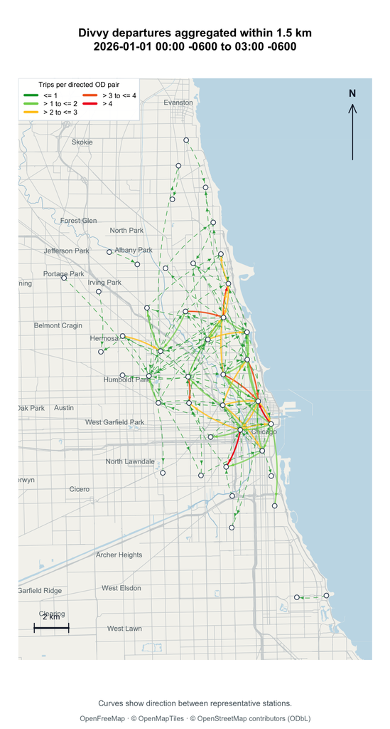

Divvy departures in the selected time window.

```r
plot_time <- params$plot_time
traffic_od_map(
  map_input_file, time_label = plot_time, basemap = basemap,
  extent = "frame", padding = 0.10,
  title = paste("Divvy departures aggregated within", aggregation_radius_m / 1000, "km"),
  caption = "Curves show direction between representative stations."
)
```

## 5 Export the results

Preparation saves its working files in a temporary directory. The draw calls use the current R graphics device. When running the blocks with `Rscript` and no device open, R can create `Rplots.pdf` in the working directory. To regenerate the report HTML and keep the selected map and complete drawing data, run this command from the example directory:

```bash
Rscript run.R 00:00 --offline --export
```

Replace `00:00` with another prepared frame start to draw that frame. The default destination is a new `output/` directory. To use a different new directory, add `--output-dir NEW_DIRECTORY`.

The command saves the selected map at `output/maps/divvy-od.png`. `output/prepared-data/od-frames.rds` contains all prepared frames and can be passed to the same plotting function to draw another frame. The `station/` and `spatial-1500m/` subdirectories hold the intermediate OD data. Each has a `source-files.csv` listing the input to that preparation step. The original trip CSV stays in `data/raw/`.